# Lab 5

Brian Teklits, Charles Doremieux, Andrew MacLean, Clint LaBattaglia

9/25/2019

### Team Plot

```r
milkteam <- milk %>%
  filter(state %in% c('New York','Colorado','California','New Jersey','Washington')) %>%
  select(state, year, milk_million)
by_year <- milkteam %>%
  group_by(year) %>%
  summarise(avg = mean(milk_million))
```

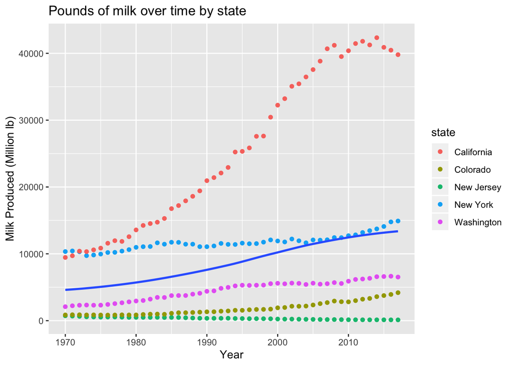

```r
ggplot(data = milkteam, aes(x = year, y = milk_million)) +
  geom_point(aes(color = state)) +
  geom_smooth(data=by_year,aes(year, avg),se=FALSE)+
  ggtitle('Pounds of milk over time by state') +
  xlab('Year') +
  ylab('Milk Produced (Million lb)')
```

#### Team Data Summary

**The year with the most milk produced:** 2017

```r
milk %>%
  group_by(year) %>%
  summarise(total_production = sum((milk_million))) %>%
  filter(total_production == max(total_production))
```

```
## # A tibble: 1 x 2
##    year total_production
##   <dbl>            <dbl>
## 1  2017           215466
```

**The year with the least milk produced:** 1975

```r
milk %>%
  group_by(year) %>%
  summarise(total_production = sum((milk_million))) %>%
  filter(total_production == min(total_production))
```

```
## # A tibble: 1 x 2
##    year total_production
##   <dbl>            <dbl>
## 1  1975           115398
```

**The top 5 milk producers of 2017:**

```r
milk %>%
  filter(year==2017) %>%
  select(state,milk_million) %>%
  arrange(desc(milk_million)) %>%
  filter(min_rank(desc(milk_million)) < 6)
```

```
##        state milk_million
## 1 California        39798
## 2  Wisconsin        30320
## 3   New York        14912
## 4      Idaho        14627
## 5      Texas        12054
```

**The bottom 5 milk producers of 2017:**

```r
milk %>%
  filter(year==2017) %>%
  select(state,milk_million) %>%
  arrange((milk_million)) %>%
  filter(min_rank((milk_million)) < 6)
```

```
##          state milk_million
## 1       Alaska            3
## 2 Rhode Island           13
## 3       Hawaii           39
## 4     Arkansas           79
## 5      Alabama           89
```

#### Reflections

**What was most helpful in learning about this data:** Exploring the various data transformation functions and how to use them in conjunction with each other made the pipe operator a lot easier to understand.

**Who could benefit the most from this analysis? Who could be harmed by it?:** We could use this data to determine states which are candidates for increasing their milk production. Increasing production in specific locations may lead to greater profits for farmers/investors.

However, the environmental effects of dairy farming are substantial. Livestock are responsible for roughly 14.5% of greenhouse gas emissions globally[^1]. Additionally, the dairy industry uses a substantial amount of water when raising livestock, around 40-50 gallons per day per cow[^2].

So, while increasing milk production in a state may lead to increased revenue, residents of that state may see increasing water costs, as well as the global negative effects of increased greenhouse gas emissions.

#### Charles’ Plot

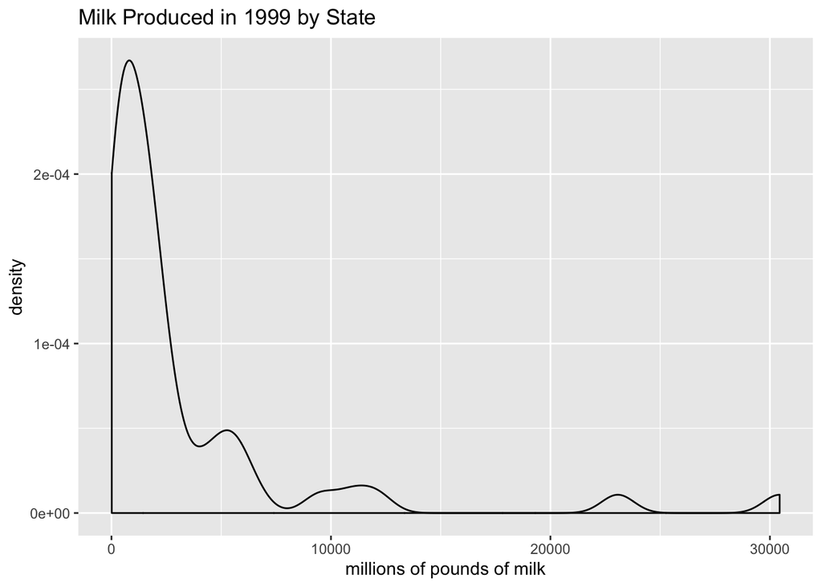

```r
milk1999 <- milk %>%
  filter(year == 1999)
ggplot(data = milk1999, aes(x = milk_million)) +
  geom_density() +
  ggtitle('Milk Produced in 1999 by State')+
  xlab("millions of pounds of milk")
```

```r
# ggplot(data = milk1999, aes(x = state, y = milk_million)) +
#   geom_col() +
#   ggtitle('Density of Milk Produced in 1999 by State')+
#   xlab("State")+
#   ylab("millions of gallons of milk")+
#   #facet_wrap(~region)+
#   theme(axis.text.x = element_text(angle=60, hjust=1))+
#   geom_text(aes(label = milk_million), vjust = -0.5)
```

**The average milk produced in year:**

```r
#calc avg
# View(milk)

milk1999 %>%
  group_by(year) %>%
  summarise(average_milk_mill = mean(milk_million))
```

```
## # A tibble: 1 x 2
##    year average_milk_mill
##   <dbl>             <dbl>
## 1  1999             3252.
```

**The median milk produced in year:**

```r
#calc median

milk1999 %>%
  group_by(year) %>%
  summarise(median_milk_mill = median(milk_million))
```

```
## # A tibble: 1 x 2
##    year median_milk_mill
##   <dbl>            <dbl>
## 1  1999             1418
```

**The top producing state of year:**

```r
#calc max

milk1999 %>%
  select(state, milk_million) %>%
  filter(milk_million == max(milk_million))
```

```
##        state milk_million
## 1 California        30444
```

**The state that produced the least in year:**

```r
#calc min

milk1999 %>%
  select(state, milk_million) %>%
  filter(milk_million == min(milk_million))
```

```
##    state milk_million
## 1 Alaska           14
```

#### Brian’s Plot

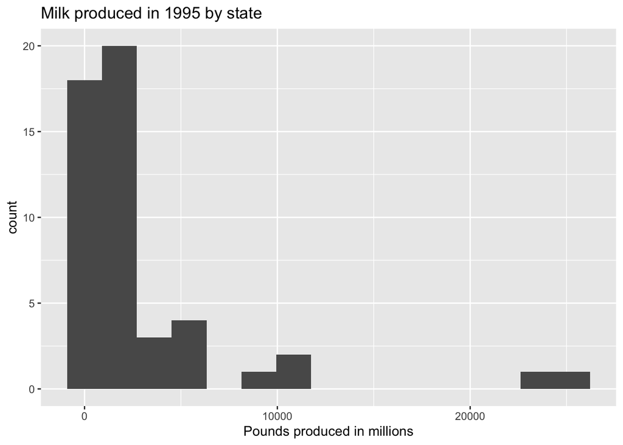

```r
milk1995 <- milk %>%
  filter(year == 1995)
ggplot(data = milk1995, aes(x = milk_million)) +
  geom_histogram(bins = 15)+
  xlab("Pounds produced in millions")+
  ggtitle('Milk produced in 1995 by state')
```

**The average milk produced in 1995:**

```r
milk1995 %>%
  summarise(avg = mean(milk_million))
```

```
##       avg
## 1 3105.86
```

**The median milk produced in 1995:**

```r
milk1995 %>%
  summarise(middle = median(milk_million))
```

```
##   middle
## 1   1512
```

**The top producing state of 1995:**

```r
milk1995 %>%
  select(state,milk_million) %>%
  filter(milk_million == max(milk_million))
```

```
##        state milk_million
## 1 California        25327
```

**The state that produced the least in 1995:**

```r
milk1995 %>%
  select(state,milk_million) %>%
  filter(milk_million == min(milk_million))
```

```
##    state milk_million
## 1 Alaska           12
```

#### Clint’s Plot

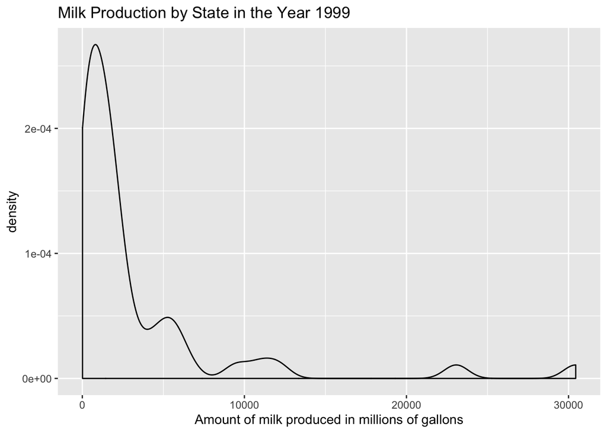

```r
milk1999 <- milk %>%
  mutate(milk_million = milk_produced/1000000) %>%
  filter(year == 1999)
ggplot(data = milk1999, mapping = aes(x = milk_million)) + geom_density() + xlab("Amount of milk produced in millions of gallons") + ggtitle("Milk Production by State in the Year 1999")
```

**The average milk produced in year:**

```r
mean_year <- milk1999 %>%
  group_by(year) %>%
  summarise(Mean = mean(milk_million)) %>%
  as_tibble()
mean_year
```

```
## # A tibble: 1 x 2
##    year  Mean
##   <dbl> <dbl>
## 1  1999 3252.
```

**The median milk produced in year:**

```r
median_year <- milk1999 %>%
  group_by(year) %>%
  summarise(Med = median(milk_million)) %>%
  as_tibble()
median_year
```

```
## # A tibble: 1 x 2
##    year   Med
##   <dbl> <dbl>
## 1  1999  1418
```

**The top producing state of year:**

```r
milk1999 %>%
  select(state,milk_million) %>%
  filter(milk_million == max(milk_million))
```

```
##        state milk_million
## 1 California        30444
```

**The state that produced the least in year:**

```r
milk1999 %>%
  select(state,milk_million) %>%
  filter(milk_million == min(milk_million))
```

```
##    state milk_million
## 1 Alaska           14
```

#### Andrew’s Plot

[figure not shown]

```r
milk1998 <- milk %>%
  filter(year == 1998)
ggplot(data = milk, mapping =  aes( x= milk_million))+
  geom_density()+
  xlab("Pounds of Milk in Millions")+
  ggtitle("Milk Produced by Each State in 1998")
```

**The average milk produced in year:**

```r
milk1998 %>%
  summarise(average = mean(milk_million))
```

```
##   average
## 1 3145.22
```

**The median milk produced in year:**

```r
milk1998 %>%
  summarise(median = median(milk_million))
```

```
##   median
## 1 1411.5
```

**The top producing state of year:**

```r
milk1998 %>%
  select(state,milk_million) %>%
  filter(milk_million == max(milk_million))
```

```
##        state milk_million
## 1 California        27620
```

**The state that produced the least in year:**

```r
milk1998 %>%
  select(state,milk_million) %>%
  filter(milk_million == min(milk_million))
```

```
##    state milk_million
## 1 Alaska           14
```